# case_study_Cyclistic

Rodrigo Cordeiro Soares

2024-09-25

## Introdução

Neste estudo, analisaremos o uso das bicicletas compartilhadas da Cyclistic, com foco em como ciclistas casuais e membros anuais utilizam o serviço de maneira diferente. O objetivo é responder às seguintes perguntas para orientar o futuro programa de marketing:

1. Como os membros anuais e os ciclistas casuais usam as bicicletas da Cyclistic de maneira diferente?
2. Por que os ciclistas casuais comprariam assinaturas anuais da Cyclistic?
3. Como a Cyclistic pode usar mídia digital para influenciar ciclistas casuais a se tornarem membros?

## Preparação dos Dados

Vamos carregar e preparar os dados de viagens para análise.

## Carregar os pacotes necessários

```r
library(ggplot2)
library(dplyr)
```

## Carregar os dados a serem utilizados

```r
dados_bicicleta2019 <- data.frame(read.csv("C:/Users/rodri/OneDrive/Documentos/estudo-bicicleta/Divvy_Trips_2019_Q1.csv",header = TRUE, sep = ","))
dados_bicicleta2020 <- data.frame(read.csv("C:/Users/rodri/OneDrive/Documentos/estudo-bicicleta/Divvy_Trips_2020_Q1.csv", header =  TRUE, sep = ","))
```

## Verificando os conjuntos de dados

```r
summary(dados_bicicleta2019) # exibe a estrutura do conjunto de 2019, além de informar se existem valores nulos(NA)
```

```
##     trip_id          start_time          end_time             bikeid
##  Min.   :21742443   Length:365069      Length:365069      Min.   :   1
##  1st Qu.:21848765   Class :character   Class :character   1st Qu.:1777
##  Median :21961829   Mode  :character   Mode  :character   Median :3489
##  Mean   :21960872                                         Mean   :3429
##  3rd Qu.:22071823                                         3rd Qu.:5157
##  Max.   :22178528                                         Max.   :6471
##
##  tripduration       from_station_id from_station_name  to_station_id
##  Length:365069      Min.   :  2.0   Length:365069      Min.   :  2.0
##  Class :character   1st Qu.: 76.0   Class :character   1st Qu.: 76.0
##  Mode  :character   Median :170.0   Mode  :character   Median :168.0
##                     Mean   :198.1                      Mean   :198.6
##                     3rd Qu.:287.0                      3rd Qu.:287.0
##                     Max.   :665.0                      Max.   :665.0
##
##  to_station_name      usertype            gender            birthyear
##  Length:365069      Length:365069      Length:365069      Min.   :1900
##  Class :character   Class :character   Class :character   1st Qu.:1975
##  Mode  :character   Mode  :character   Mode  :character   Median :1985
##                                                           Mean   :1982
##                                                           3rd Qu.:1990
##                                                           Max.   :2003
##                                                           NA's   :18023
##  ryde_lenght         day_of_week
##  Length:365069      Min.   :1.000
##  Class :character   1st Qu.:3.000
##  Mode  :character   Median :4.000
##                     Mean   :4.144
##                     3rd Qu.:6.000
##                     Max.   :7.000
##
```

```r
str(dados_bicicleta2019) # exibe a estrutura do conjunto de 2019
```

```
## 'data.frame':    365069 obs. of  14 variables:
##  $ trip_id          : int  21742443 21742444 21742445 21742446 21742447 21742448 21742449 21742450 21742451 21742452 ...
##  $ start_time       : chr  "1/1/2019 0:04" "1/1/2019 0:08" "1/1/2019 0:13" "1/1/2019 0:13" ...
##  $ end_time         : chr  "1/1/2019 0:11" "1/1/2019 0:15" "1/1/2019 0:27" "1/1/2019 0:43" ...
##  $ bikeid           : int  2167 4386 1524 252 1170 2437 2708 2796 6205 3939 ...
##  $ tripduration     : chr  "390" "441" "829" "1,783.00" ...
##  $ from_station_id  : int  199 44 15 123 173 98 98 211 150 268 ...
##  $ from_station_name: chr  "Wabash Ave & Grand Ave" "State St & Randolph St" "Racine Ave & 18th St" "California Ave & Milwaukee Ave" ...
##  $ to_station_id    : int  84 624 644 176 35 49 49 142 148 141 ...
##  $ to_station_name  : chr  "Milwaukee Ave & Grand Ave" "Dearborn St & Van Buren St (*)" "Western Ave & Fillmore St (*)" "Clark St & Elm St" ...
##  $ usertype         : chr  "Subscriber" "Subscriber" "Subscriber" "Subscriber" ...
##  $ gender           : chr  "Male" "Female" "Female" "Male" ...
##  $ birthyear        : int  1989 1990 1994 1993 1994 1983 1984 1990 1995 1996 ...
##  $ ryde_lenght      : chr  "12:07:00 AM" "12:07:00 AM" "12:14:00 AM" "12:30:00 AM" ...
##  $ day_of_week      : int  3 3 3 3 3 3 3 3 3 3 ...
```

```r
summary(dados_bicicleta2020) # exibe a estrutura do conjunto de 2020, além de informar se existem valores nulos(NA)
```

```
##    ride_id          rideable_type       started_at          ended_at
##  Length:426887      Length:426887      Length:426887      Length:426887
##  Class :character   Class :character   Class :character   Class :character
##  Mode  :character   Mode  :character   Mode  :character   Mode  :character
##
##
##
##
##  start_station_name start_station_id end_station_name   end_station_id
##  Length:426887      Min.   :  2.0    Length:426887      Min.   :  2.0
##  Class :character   1st Qu.: 77.0    Class :character   1st Qu.: 77.0
##  Mode  :character   Median :176.0    Mode  :character   Median :175.0
##                     Mean   :209.8                       Mean   :209.3
##                     3rd Qu.:298.0                       3rd Qu.:297.0
##                     Max.   :675.0                       Max.   :675.0
##                                                         NA's   :1
##    start_lat       start_lng         end_lat         end_lng
##  Min.   :41.74   Min.   :-87.77   Min.   :41.74   Min.   :-87.77
##  1st Qu.:41.88   1st Qu.:-87.66   1st Qu.:41.88   1st Qu.:-87.66
##  Median :41.89   Median :-87.64   Median :41.89   Median :-87.64
##  Mean   :41.90   Mean   :-87.64   Mean   :41.90   Mean   :-87.64
##  3rd Qu.:41.92   3rd Qu.:-87.63   3rd Qu.:41.92   3rd Qu.:-87.63
##  Max.   :42.06   Max.   :-87.55   Max.   :42.06   Max.   :-87.55
##                                   NA's   :1       NA's   :1
##  member_casual      ryde_lenght         day_of_week
##  Length:426887      Length:426887      Min.   :1.000
##  Class :character   Class :character   1st Qu.:2.000
##  Mode  :character   Mode  :character   Median :4.000
##                                        Mean   :3.857
##                                        3rd Qu.:5.000
##                                        Max.   :7.000
##
```

```r
str(dados_bicicleta2020) # exibe a estrutura do conjunto de 2020
```

```
## 'data.frame':    426887 obs. of  15 variables:
##  $ ride_id           : chr  "EACB19130B0CDA4A" "8FED874C809DC021" "789F3C21E472CA96" "C9A388DAC6ABF313" ...
##  $ rideable_type     : chr  "docked_bike" "docked_bike" "docked_bike" "docked_bike" ...
##  $ started_at        : chr  "2020-01-21 20:06:59" "2020-01-30 14:22:39" "2020-01-09 19:29:26" "2020-01-06 16:17:07" ...
##  $ ended_at          : chr  "2020-01-21 20:14:30" "2020-01-30 14:26:22" "2020-01-09 19:32:17" "2020-01-06 16:25:56" ...
##  $ start_station_name: chr  "Western Ave & Leland Ave" "Clark St & Montrose Ave" "Broadway & Belmont Ave" "Clark St & Randolph St" ...
##  $ start_station_id  : int  239 234 296 51 66 212 96 96 212 38 ...
##  $ end_station_name  : chr  "Clark St & Leland Ave" "Southport Ave & Irving Park Rd" "Wilton Ave & Belmont Ave" "Fairbanks Ct & Grand Ave" ...
##  $ end_station_id    : int  326 318 117 24 212 96 212 212 96 100 ...
##  $ start_lat         : num  42 42 41.9 41.9 41.9 ...
##  $ start_lng         : num  -87.7 -87.7 -87.6 -87.6 -87.6 ...
##  $ end_lat           : num  42 42 41.9 41.9 41.9 ...
##  $ end_lng           : num  -87.7 -87.7 -87.7 -87.6 -87.6 ...
##  $ member_casual     : chr  "member" "member" "member" "member" ...
##  $ ryde_lenght       : chr  "12:07:31 AM" "12:03:43 AM" "12:02:51 AM" "12:08:49 AM" ...
##  $ day_of_week       : int  3 5 5 2 5 6 6 6 6 6 ...
```

Após a análise utlizando os comandos str e summary, nota-se a presença de valores faltantes principalmente no conjunto de 2019 Em que dados como gênero e ano de nascimento não estão completos nas colunas respectivas, essa falta levou a conclusão da necessidade da limpeza e exclusão desdes dados faltantes, pois para ser possível traçar o perfil que diferencia um assinante casual de um anual é necessário traçar um perfil de usúario.

## Limpeza dos conjuntos de dados

```r
# Exclui todas as linhas que contêm valores NA de 2019
cyclistic_data_limpo_2019 <- na.omit(dados_bicicleta2019)
cyclistic_data_limpo_2020 <- na.omit(dados_bicicleta2020)
```

## Transformação dos dados

Embora ambas as tabelas possuam colunas e atributos diferentes, observa-se que há colunas que representam as mesmas informações, mas estão nomeadas de forma diferente ou possuem classes de atributos distintas. Nesta seção do código, realizaremos a normalização dessas colunas, padronizando os nomes e ajustando as classes de dados para garantir consistência.

```r
# Padronizar nomes de colunas no dataset de 2020 para que coincidam com 2019
cyclistic_data_limpo_2020 <- cyclistic_data_limpo_2020 %>%
  rename(
    trip_id = ride_id,        # padronizar o nome da coluna ride_id
    start_time = started_at,          # Padronizar o nome da coluna 'started_at'
    end_time = ended_at,              # Padronizar o nome da coluna 'ended_at'
    usertype = member_casual       # Exemplo para padronizar o nome da coluna de tipo de usuário
  )
```

```r
# verificando a alteração dos nome das colunas
colnames(cyclistic_data_limpo_2020)
```

```
##  [1] "trip_id"            "rideable_type"      "start_time"
##  [4] "end_time"           "start_station_name" "start_station_id"
##  [7] "end_station_name"   "end_station_id"     "start_lat"
## [10] "start_lng"          "end_lat"            "end_lng"
## [13] "usertype"           "ryde_lenght"        "day_of_week"
```

Após alterar o nome das colunas, agora iremos normalizar os valores para o tipo de usuário, onde na base de 2019 é subscriber e costumer e para base de 2020 está como member e casual. Aqui iremos normalizar para member e casual, pois são valores mais descritivos.

```r
# Alterar valores da coluna usertype usando ifelse()
cyclistic_data_limpo_2019 <- cyclistic_data_limpo_2019 %>%
  mutate(
    usertype = ifelse(usertype == "Subscriber", "member",
                      ifelse(usertype == "Customer", "casual", usertype))
  )

# Verificar as alterações
table(cyclistic_data_limpo_2020$usertype)
```

```
##
## casual member
##  48479 378407
```

Convertendo a coluna “ryde_lenght” para segundos para possibilitar o uso dos valores de duração de cada corrida em cálculos mais a frente no estudo.

```r
library(lubridate)
cyclistic_data_limpo_2019 <- cyclistic_data_limpo_2019 %>%
  mutate(ryde_lenght_seconds = as.numeric(hms(ryde_lenght)))  # Convertendo para segundos em 2019
```

```r
library(lubridate)
cyclistic_data_limpo_2020 <- cyclistic_data_limpo_2020 %>%
  mutate(ryde_lenght_seconds = as.numeric(hms(ryde_lenght)))  # Convertendo para segundos em 2020
```

Manipulação da coluna end_time para recolher os meses em que as corridas foram registradas

```r
# Carregar a biblioteca lubridate para manipulação de datas
library(lubridate)
# Converter a coluna end_time para formato de data e extrair o mês
cyclistic_data_limpo_2019 <- cyclistic_data_limpo_2019 %>%
  mutate(end_time = mdy_hm(end_time),  # Converte para o formato de data e hora
         month = month(end_time, label = TRUE))  # Extrai o mês

# Verificar se a conversão deu certo
head(cyclistic_data_limpo_2019)
```

```
##    trip_id    start_time            end_time bikeid tripduration
## 1 21742443 1/1/2019 0:04 2019-01-01 00:11:00   2167          390
## 2 21742444 1/1/2019 0:08 2019-01-01 00:15:00   4386          441
## 3 21742445 1/1/2019 0:13 2019-01-01 00:27:00   1524          829
## 4 21742446 1/1/2019 0:13 2019-01-01 00:43:00    252     1,783.00
## 5 21742447 1/1/2019 0:14 2019-01-01 00:20:00   1170          364
## 6 21742448 1/1/2019 0:15 2019-01-01 00:19:00   2437          216
##   from_station_id                   from_station_name to_station_id
## 1             199              Wabash Ave & Grand Ave            84
## 2              44              State St & Randolph St           624
## 3              15                Racine Ave & 18th St           644
## 4             123      California Ave & Milwaukee Ave           176
## 5             173 Mies van der Rohe Way & Chicago Ave            35
## 6              98          LaSalle St & Washington St            49
##                  to_station_name usertype gender birthyear ryde_lenght
## 1      Milwaukee Ave & Grand Ave   member   Male      1989 12:07:00 AM
## 2 Dearborn St & Van Buren St (*)   member Female      1990 12:07:00 AM
## 3  Western Ave & Fillmore St (*)   member Female      1994 12:14:00 AM
## 4              Clark St & Elm St   member   Male      1993 12:30:00 AM
## 5        Streeter Dr & Grand Ave   member   Male      1994 12:06:00 AM
## 6        Dearborn St & Monroe St   member Female      1983 12:04:00 AM
##   day_of_week ryde_lenght_seconds month
## 1           3               43620   Jan
## 2           3               43620   Jan
## 3           3               44040   Jan
## 4           3               45000   Jan
## 5           3               43560   Jan
## 6           3               43440   Jan
```

```r
# Carregar a biblioteca lubridate para manipulação de datas
library(lubridate)
# Converter a coluna end_time para formato de data e extrair o mês
cyclistic_data_limpo_2020 <- cyclistic_data_limpo_2020 %>%
  mutate(end_time = ymd_hms(end_time),  # Converte para o formato de data e hora
         month = month(end_time, label = TRUE))  # Extrai o mês

# Verificar se a conversão deu certo
head(cyclistic_data_limpo_2020)
```

```
##            trip_id rideable_type          start_time            end_time
## 1 EACB19130B0CDA4A   docked_bike 2020-01-21 20:06:59 2020-01-21 20:14:30
## 2 8FED874C809DC021   docked_bike 2020-01-30 14:22:39 2020-01-30 14:26:22
## 3 789F3C21E472CA96   docked_bike 2020-01-09 19:29:26 2020-01-09 19:32:17
## 4 C9A388DAC6ABF313   docked_bike 2020-01-06 16:17:07 2020-01-06 16:25:56
## 5 943BC3CBECCFD662   docked_bike  2020-01-30 8:37:16 2020-01-30 08:42:48
## 6 6D9C8A6938165C11   docked_bike 2020-01-10 12:33:05 2020-01-10 12:37:54
##         start_station_name start_station_id               end_station_name
## 1 Western Ave & Leland Ave              239          Clark St & Leland Ave
## 2  Clark St & Montrose Ave              234 Southport Ave & Irving Park Rd
## 3   Broadway & Belmont Ave              296       Wilton Ave & Belmont Ave
## 4   Clark St & Randolph St               51       Fairbanks Ct & Grand Ave
## 5     Clinton St & Lake St               66          Wells St & Hubbard St
## 6    Wells St & Hubbard St              212    Desplaines St & Randolph St
##   end_station_id start_lat start_lng end_lat  end_lng usertype ryde_lenght
## 1            326   41.9665  -87.6884 41.9671 -87.6674   member 12:07:31 AM
## 2            318   41.9616  -87.6660 41.9542 -87.6644   member 12:03:43 AM
## 3            117   41.9401  -87.6455 41.9402 -87.6530   member 12:02:51 AM
## 4             24   41.8846  -87.6319 41.8918 -87.6206   member 12:08:49 AM
## 5            212   41.8856  -87.6418 41.8899 -87.6343   member 12:05:32 AM
## 6             96   41.8899  -87.6343 41.8846 -87.6446   member 12:04:49 AM
##   day_of_week ryde_lenght_seconds month
## 1           3               43651   Jan
## 2           5               43423   Jan
## 3           5               43371   Jan
## 4           2               43729   Jan
## 5           5               43532   Jan
## 6           6               43489   Jan
```

## Análise: Diferenças no Uso entre Membros Anuais e Ciclistas Casuais

Nesta seção, analisaremos as diferenças de comportamento entre os dois grupos de usuários. Utilizaremos uma variedade de gráficos e técnicas estatísticas para identificar padrões de uso em cada grupo, com o objetivo de converter ciclistas casuais em clientes fidelizados.

A análise permitirá insights mais profundos sobre o perfil dos usuários e ajudará na formulação de estratégias eficazes para aumentar a adesão às assinaturas anuais.

### Contagem de viagens por tipo de usuário de 2019

```r
trip_counts_2019 <- cyclistic_data_limpo_2019 %>%
  group_by(usertype) %>%
  summarise(count = n())
```

### Gráfico de barras referente a contagem de viagens por tipo de usuário em 2019

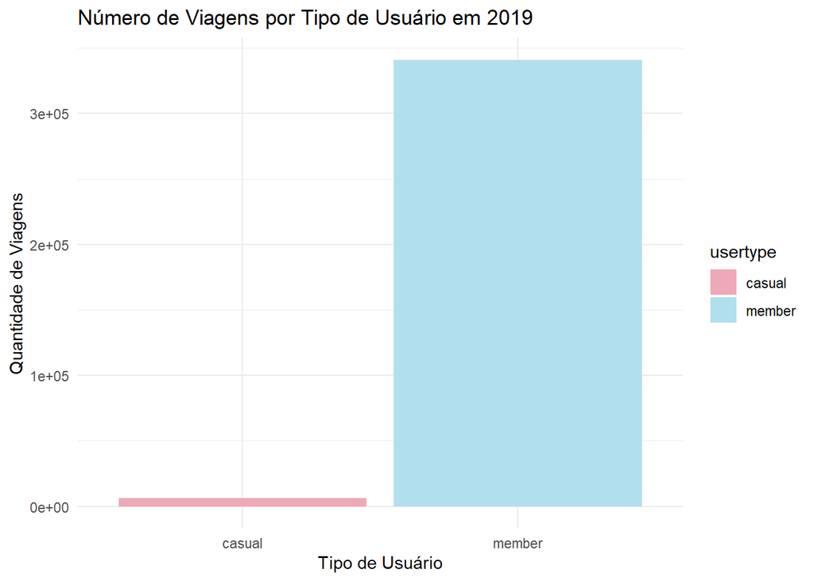

```r
# Código que gera o gráfico referente a contagem por tipo de usúario em 2019
ggplot(trip_counts_2019, aes(x = usertype, y = count, fill = usertype)) +
  geom_bar(stat = "identity") +  # Define que a altura da barra será o valor em 'count'
  labs(title = "Número de Viagens por Tipo de Usuário em 2019",
       x = "Tipo de Usuário", y = "Quantidade de Viagens") +
  scale_fill_manual(values = c("casual" = "pink2", "member" = "lightblue2")) +  # Define as cores para os tipos de usuário
  theme_minimal()
```

### Contagem de viagens por tipo de usuário de 2020

```r
trip_counts_2020 <- cyclistic_data_limpo_2020 %>%
  group_by(usertype) %>%
  summarise(count = n())
```

### Gráfico de barras referente a contagem de viagens por tipo de usuário em 2020

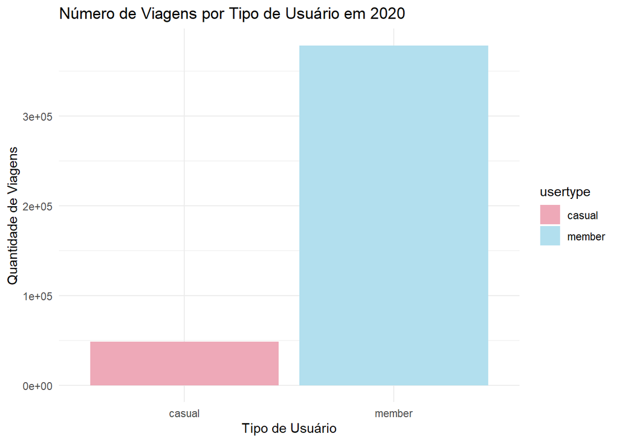

```r
# Código que gera o gráfico referente a contagem por tipo de usúario em 2020
ggplot(trip_counts_2020, aes(x = usertype, y = count, fill = usertype)) +
  geom_bar(stat = "identity") +  # Define que a altura da barra será o valor em 'count'
  labs(title = "Número de Viagens por Tipo de Usuário em 2020",
       x = "Tipo de Usuário", y = "Quantidade de Viagens") +
  scale_fill_manual(values = c("casual" = "pink2", "member" = "lightblue2")) +  # Define as cores para os tipos de usuário
  theme_minimal()
```

Analisando os gráficos um por um é perceptível que, o maior número de usuários se concentra em membros, porém de 2019 a 2020 o número de membros casuais aumentou por volta de 8 vezes enquanto enquanto o de membros não cresceu tanto. O que significa que o principal foco da empresa tem que ser voltado em converter os usuários já cadastrados.

### Gráfico de linhas referente ao uso pelos dias da semana

```r
usage_by_day <- cyclistic_data_limpo_2019 %>%
  group_by(usertype, day_of_week) %>%
  summarise(count = n())
```

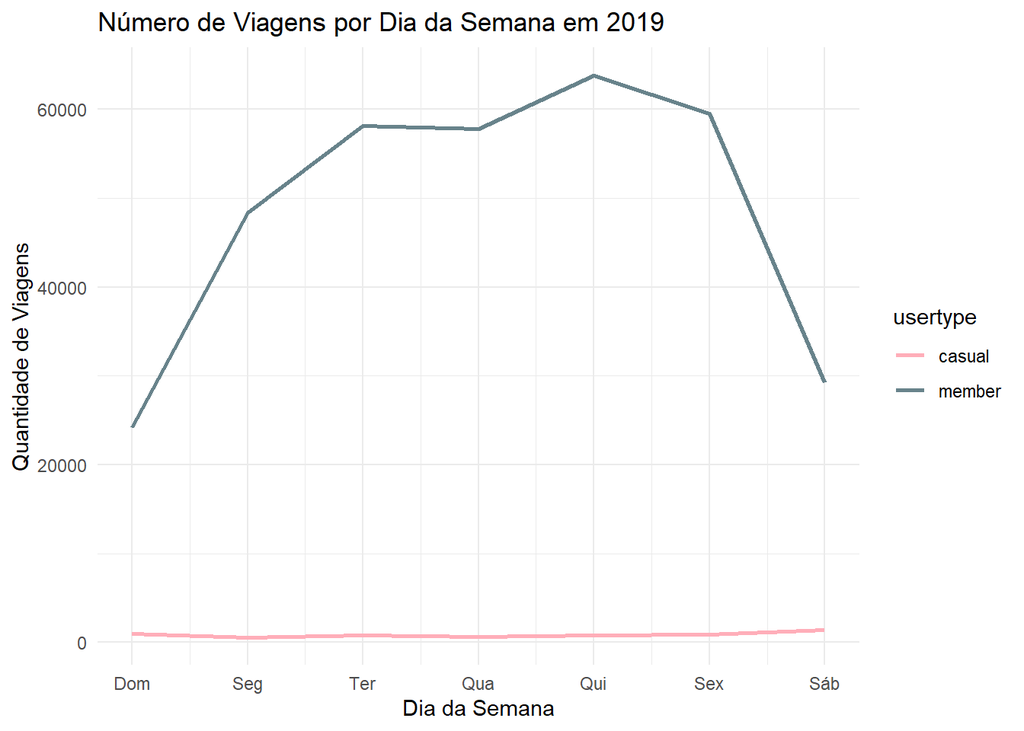

```r
# Criando gráfico de linhas
ggplot(usage_by_day, aes(x = day_of_week, y = count, color = usertype)) +
  geom_line(size = 1) +
  labs(title = "Número de Viagens por Dia da Semana em 2019", x = "Dia da Semana", y = "Quantidade de Viagens") +
  scale_color_manual(values = c("casual" = "lightpink1", "member" = "lightblue4")) +
  theme_minimal() +
  scale_x_continuous(breaks = 1:7, labels = c("Dom", "Seg", "Ter", "Qua", "Qui", "Sex", "Sáb"))
```

```r
usage_by_day <- cyclistic_data_limpo_2020 %>%
  group_by(usertype, day_of_week) %>%
  summarise(count = n())
```

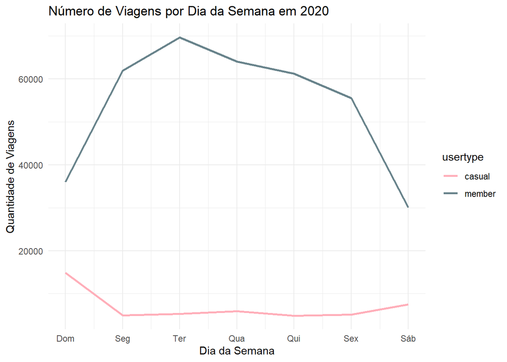

```r
# Criando gráfico de linhas para o ano de 2020
ggplot(usage_by_day, aes(x = day_of_week, y = count, color = usertype)) +
  geom_line(size = 1) +
  labs(title = "Número de Viagens por Dia da Semana em 2020", x = "Dia da Semana", y = "Quantidade de Viagens") +
  scale_color_manual(values = c("casual" = "lightpink1", "member" = "lightblue4")) +
  theme_minimal() +
  scale_x_continuous(breaks = 1:7, labels = c("Dom", "Seg", "Ter", "Qua", "Qui", "Sex", "Sáb"))
```

Por outro lado, os ciclistas casuais concentram seu uso principalmente nos finais de semana, o que indica que eles utilizam as bicicletas mais para lazer ou atividades recreativas. Motivos para Ciclistas Casuais se Tornarem Membros Aqui exploramos as razões pelas quais ciclistas casuais podem optar por se tornar membros anuais, como custo-benefício e conveniência.

### Gráfico de Barras para duração média de cada corrida:

Duração Média das Viagens Os gráficos de barras abaixo apresenta a duração média das viagens realizadas por membros anuais e ciclistas casuais. Ele permite uma comparação direta entre os dois grupos, destacando como cada tipo de usuário utiliza o serviço em termos de tempo. Essa visualização é essencial para entender os hábitos de uso, ajudando a identificar se ciclistas casuais tendem a fazer viagens mais longas ou se os membros anuais utilizam o serviço de forma mais eficiente e frequente.

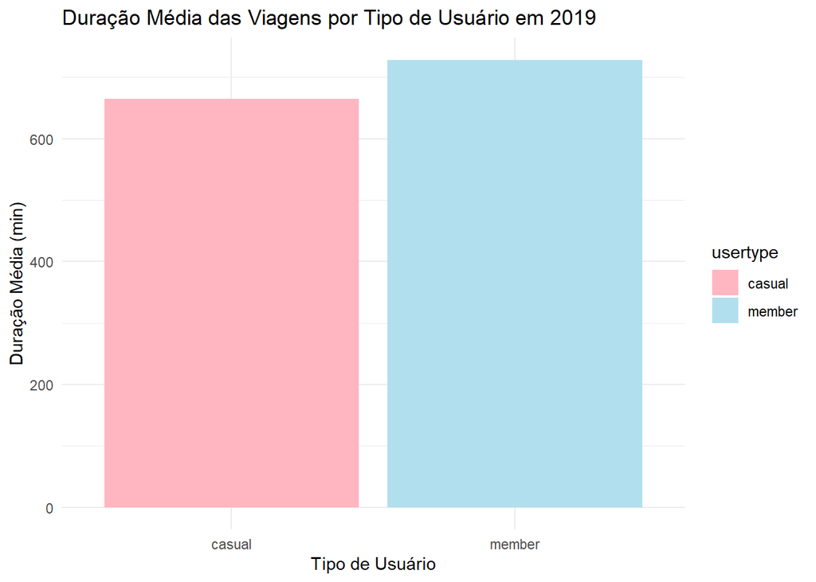

```r
avg_ride_length <- cyclistic_data_limpo_2019 %>%
  group_by(usertype) %>%
  summarise(avg_duration = mean(ryde_lenght_seconds, na.rm = TRUE) / 60)

# Gráfico de barras para duração média
ggplot(avg_ride_length, aes(x = usertype, y = avg_duration, fill = usertype)) +
  geom_col() +  # Usando geom_col
  labs(title = "Duração Média das Viagens por Tipo de Usuário em 2019",
       x = "Tipo de Usuário",
       y = "Duração Média (min)") +
  scale_fill_manual(values = c("casual" = "lightpink", "member" = "lightblue2")) +
  theme_minimal()
```

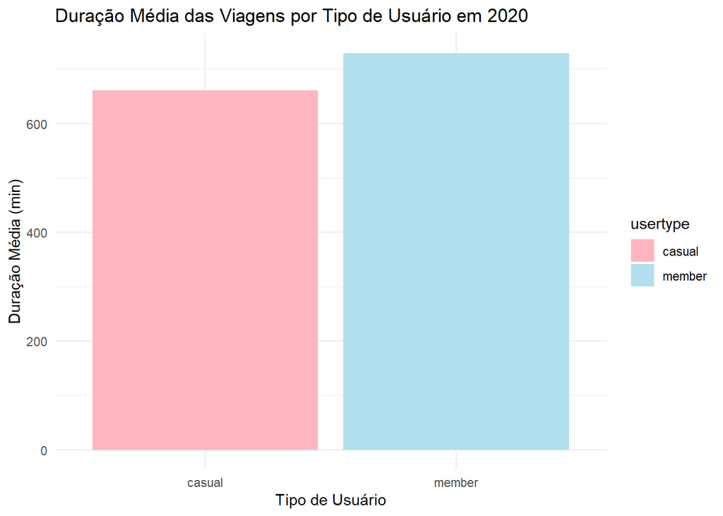

```r
avg_ride_length <- cyclistic_data_limpo_2020 %>%
  group_by(usertype) %>%
  summarise(avg_duration = mean(ryde_lenght_seconds, na.rm = TRUE) / 60)

# Gráfico de barras para duração média
ggplot(avg_ride_length, aes(x = usertype, y = avg_duration, fill = usertype)) +
  geom_col() +  # Usando geom_col
  labs(title = "Duração Média das Viagens por Tipo de Usuário em 2020",
       x = "Tipo de Usuário",
       y = "Duração Média (min)") +
  scale_fill_manual(values = c("casual" = "lightpink", "member" = "lightblue2")) +
  theme_minimal()
```

Agora vamos gerar um gráfico que apresenta as 10 estações mais populares entre os usuários. Com essa análise, será possível identificar as áreas de maior concentração de clientes e investigar as razões que levam à alta demanda nesses locais.

```r
station_usage <- cyclistic_data_limpo_2019 %>%
  group_by(from_station_name, usertype) %>%
  summarise(total_trips = n()) %>%
  ungroup()
```

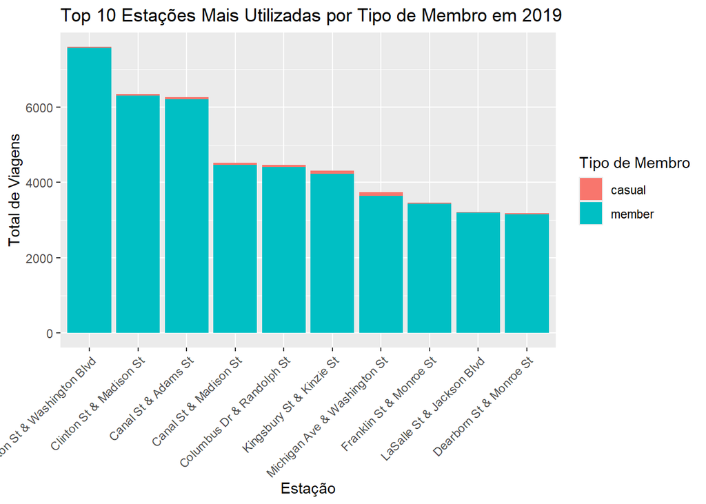

```r
# Filtrar as 10 estações mais populares
top_stations <- station_usage %>%
  group_by(from_station_name) %>%
  summarise(total = sum(total_trips)) %>%
  top_n(10, total)

# Filtrar os dados para essas estações
station_usage_top <- station_usage %>%
  filter(from_station_name %in% top_stations$from_station_name)

# Criar o gráfico
ggplot(station_usage_top, aes(x = reorder(from_station_name, -total_trips), y = total_trips, fill = usertype)) +
  geom_bar(stat = "identity") +
  labs(title = "Top 10 Estações Mais Utilizadas por Tipo de Membro em 2019",
       x = "Estação",
       y = "Total de Viagens",
       fill = "Tipo de Membro") +
  theme(axis.text.x = element_text(angle = 45, hjust = 1))
```

```r
station_usage <- cyclistic_data_limpo_2020 %>%
  group_by(start_station_name, usertype) %>%
  summarise(total_trips = n()) %>%
  ungroup()
```

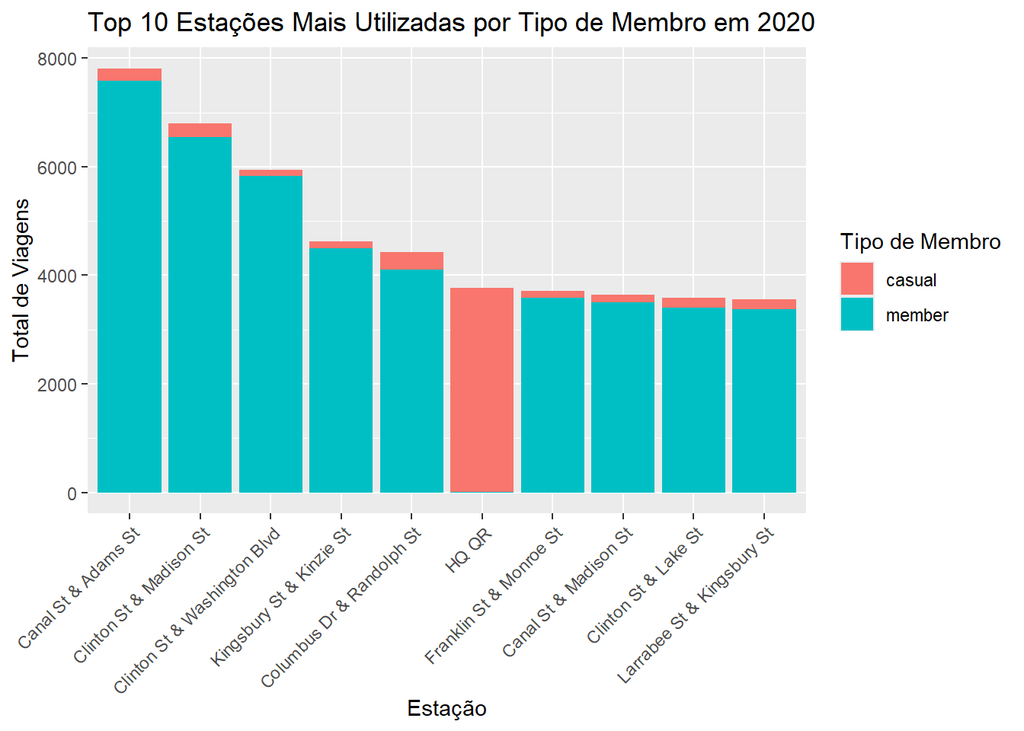

```r
# Filtrar as 10 estações mais populares
top_stations <- station_usage %>%
  group_by(start_station_name) %>%
  summarise(total = sum(total_trips)) %>%
  top_n(10, total)

# Filtrar os dados para essas estações
station_usage_top <- station_usage %>%
  filter(start_station_name %in% top_stations$start_station_name)

# Criar o gráfico
ggplot(station_usage_top, aes(x = reorder(start_station_name, -total_trips), y = total_trips, fill = usertype)) +
  geom_bar(stat = "identity") +
  labs(title = "Top 10 Estações Mais Utilizadas por Tipo de Membro em 2020",
       x = "Estação",
       y = "Total de Viagens",
       fill = "Tipo de Membro") +
  theme(axis.text.x = element_text(angle = 45, hjust = 1))
```

### Estratégia de Mídia Digital

Finalmente, discutiremos como o uso de mídia digital pode influenciar os ciclistas casuais a se tornarem membros Para isto utilizaremos um Gráfico de Calor sobre o Uso por Mês e Tipo de Usuário.

O gráfico abaixo mostra a sazonalidade no uso das bicicletas para os dois tipos de usuários.

```r
# Uso das bicicletas por mês e tipo de usuário
usage_by_month <- cyclistic_data_limpo_2019 %>%
  group_by(usertype, month) %>%
  summarise(count = n())
```

[figure not shown]

```r
# Gráfico de calo
ggplot(usage_by_month, aes(x = month, y = usertype, fill = count)) +
  geom_tile() +
  labs(title = "Uso de Bicicletas por tipo de usúario nos primeiros meses de 2020",
       x = "Mês",
       y = "Tipo de Usuário") +
  scale_fill_gradient(low = "lightyellow", high = "red1") +
  theme_minimal() +
  theme(axis.text.x = element_text(angle = 45, hjust = 1))  # Melhorar a legibilidade dos rótulos do eixo X
```

```r
# Uso das bicicletas por mês e tipo de usuário
usage_by_month <- cyclistic_data_limpo_2020 %>%
  group_by(usertype, month) %>%
  summarise(count = n())
```

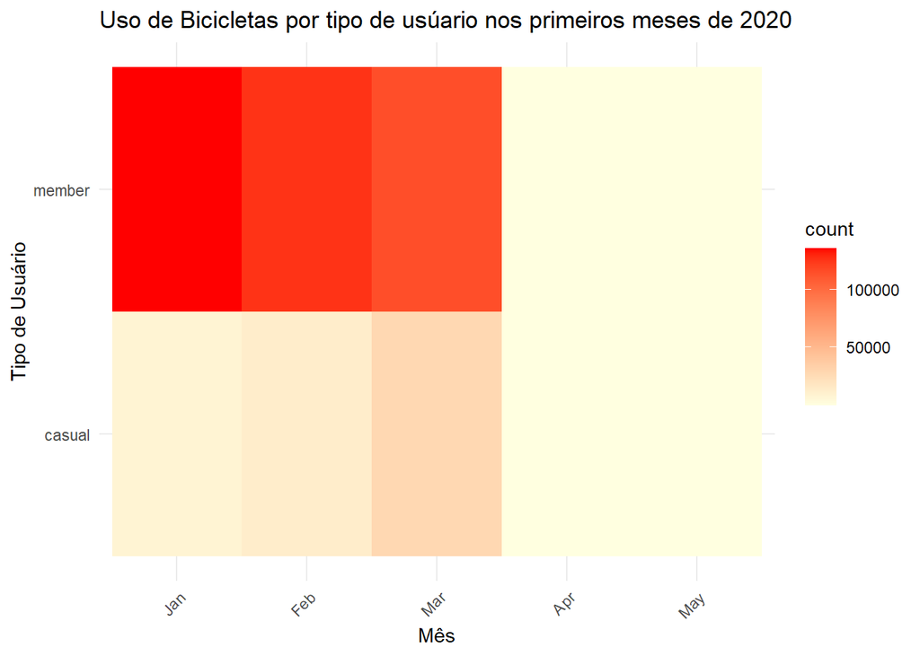

```r
# Gráfico de calo
ggplot(usage_by_month, aes(x = month, y = usertype, fill = count)) +
  geom_tile() +
  labs(title = "Uso de Bicicletas por tipo de usúario nos primeiros meses de 2020",
       x = "Mês",
       y = "Tipo de Usuário") +
  scale_fill_gradient(low = "lightyellow", high = "red1") +
  theme_minimal() +
  theme(axis.text.x = element_text(angle = 45, hjust = 1))  # Melhorar a legibilidade dos rótulos do eixo X
```

## Conclusão

Os gráficos e análises apresentados destacam de forma clara as diferenças de comportamento entre ciclistas casuais e membros anuais, revelando padrões de uso distintos. As descobertas sugerem uma oportunidade significativa para converter ciclistas casuais em membros anuais por meio de campanhas digitais direcionadas, com foco na conveniência e no custo-benefício do plano de assinatura.

Ao explorar essas regiões específicas com comunicação direcionada, a Cyclistic pode aumentar suas chances de conversão, incentivando os usuários casuais a optarem pela assinatura, com base em suas necessidades de mobilidade e economia a longo prazo.

Em resumo, o estudo revela que, com estratégias bem planejadas e baseadas nos dados, há um potencial significativo para aumentar a fidelização e a base de membros anuais, impulsionando o crescimento sustentável da Cyclistic.